# Stat 361 - Recitation1 (R review)

Serenay Çakar

2026-02-19

Mail Address: serenay@metu.edu.tr

Office No: 234

Office Phone: +90 (312) 210-2979

# Question 1

Create the following objects.

```r
# a
vec_a <- seq(from = 100, to = 50, by = -2)
print(vec_a)
```

```
##  [1] 100  98  96  94  92  90  88  86  84  82  80  78  76  74  72  70  68  66  64
## [20]  62  60  58  56  54  52  50
```

```r
# b
vec_b <- rep(x = c(2, 4, 6, 8), times = 5)
print(vec_b)
```

```
##  [1] 2 4 6 8 2 4 6 8 2 4 6 8 2 4 6 8 2 4 6 8
```

```r
# c
vec_c <- rep(x = c(10, 20, 30), times = 3, each = 2)
print(vec_c)
```

```
##  [1] 10 10 20 20 30 30 10 10 20 20 30 30 10 10 20 20 30 30
```

# Question 2

Create the following objects.

- 1. Create a 4×2 matrix with random values from a normal distribution, $N(\mu=3, \sigma^2=4)$.

```r
set.seed(361)  # Ensures reproducibility
matrix_norm <- matrix(rnorm(8, mean=3, sd=2), nrow = 4, ncol = 2)
print(matrix_norm)
```

```
##          [,1]      [,2]
## [1,] 3.723120 3.1048768
## [2,] 4.403609 0.6981447
## [3,] 1.946390 5.1922677
## [4,] 3.145338 2.8755207
```

- 2. Create a 3×3 identity matrix.

```r
matrix_ident <- diag(3)
print(matrix_ident)
```

```
##      [,1] [,2] [,3]
## [1,]    1    0    0
## [2,]    0    1    0
## [3,]    0    0    1
```

- 3. Create a 6×6 checkerboard matrix where the elements alternate between 1 and 0, like a chessboard pattern.

[figure not shown]

```r
# Define matrix size
n <- 6

# Initialize an empty n x n matrix
matrix_checkerboard <- matrix(0, nrow = n, ncol = n)

# Fill the matrix using a for loop
for (i in 1:n) {
  for (j in 1:n) {
    if ((i + j) %% 2 == 0) {
      matrix_checkerboard[i, j] <- 1  # Set 1 for even sum of row and column indices
    }
  }
}

# Print the resulting checkerboard matrix
print(matrix_checkerboard)
```

```
##      [,1] [,2] [,3] [,4] [,5] [,6]
## [1,]    1    0    1    0    1    0
## [2,]    0    1    0    1    0    1
## [3,]    1    0    1    0    1    0
## [4,]    0    1    0    1    0    1
## [5,]    1    0    1    0    1    0
## [6,]    0    1    0    1    0    1
```

- 4. Define a function to generate the question in part (c) for different matrix sizes.

```r
create_checkerboard_matrix <- function(n) {

    matrix_checkerboard <- matrix(0, nrow = n, ncol = n)

  for (i in 1:n) {
    for (j in 1:n) {
      if ((i + j) %% 2 == 0) {
        matrix_checkerboard[i, j] <- 1
      }
    }
  }

  return(matrix_checkerboard)
}

create_checkerboard_matrix(6)
```

```
##      [,1] [,2] [,3] [,4] [,5] [,6]
## [1,]    1    0    1    0    1    0
## [2,]    0    1    0    1    0    1
## [3,]    1    0    1    0    1    0
## [4,]    0    1    0    1    0    1
## [5,]    1    0    1    0    1    0
## [6,]    0    1    0    1    0    1
```

- 5. Generate the following matrices and perform matrix calculations.

Matrix $A$ is a **3×3** matrix:

$$A = \begin{pmatrix}
1 & 2 & 3 \\
4 & 5 & 6 \\
7 & 8 & 9
\end{pmatrix}$$

```r
A <- matrix(1:9, nrow = 3, byrow = TRUE)
A
```

```
##      [,1] [,2] [,3]
## [1,]    1    2    3
## [2,]    4    5    6
## [3,]    7    8    9
```

Matrix $B$ is a **3×3** matrix:

$$B = \begin{pmatrix}
9 & 8 & 7 \\
6 & 5 & 4 \\
3 & 2 & 1
\end{pmatrix}$$

```r
B <- matrix(9:1, ncol=3, byrow = TRUE)
B
```

```
##      [,1] [,2] [,3]
## [1,]    9    8    7
## [2,]    6    5    4
## [3,]    3    2    1
```

- 1. Obtain the transpose of matrix A.

```r
t(A)
```

```
##      [,1] [,2] [,3]
## [1,]    1    4    7
## [2,]    2    5    8
## [3,]    3    6    9
```

- 2. Multiply matrix A with the transpose of matrix B.

```r
mat_mult <- A %*% t(B)
mat_mult
```

```
##      [,1] [,2] [,3]
## [1,]   46   28   10
## [2,]  118   73   28
## [3,]  190  118   46
```

- 3. Create a new matrix with (2nd and 3rd) rows and (1st and 3rd) columns of A.

```r
subset_A <- A[c(2,3),c(1,3)]
subset_A
```

```
##      [,1] [,2]
## [1,]    4    6
## [2,]    7    9
```

```r
# Or, you can use "-" to exclude some rows or columns
subset_A2 <- A[-1,-2]
subset_A2
```

```
##      [,1] [,2]
## [1,]    4    6
## [2,]    7    9
```

- 4. Compute the mean of each column and row, separately. (Please do not use any loop)

```r
colMeans(A)
```

```
## [1] 4 5 6
```

```r
rowMeans(A)
```

```
## [1] 2 5 8
```

```r
apply(A,2,mean)
```

```
## [1] 4 5 6
```

```r
apply(A,1,mean)
```

```
## [1] 2 5 8
```

# Question 3

Count the number of even numbers in a vector $x=[5,2,6,8,42,3,11,17,29,56,77]$.

```r
x <- c(5,2,6,8,42,3,11,17,29,56,77)

length(which(x %% 2 == 0)) #finds the ones divisible with 2 (since they are even) and takes the length of them
```

```
## [1] 5
```

```r
## OR ##

count <- 0
for(i in 1:length(x)){
  if(x[i] %% 2 == 0)
    count = count + 1
}

print(count)
```

```
## [1] 5
```

```r
## OR ##

sum(ifelse(x %% 2 == 0, 1 ,0))
```

```
## [1] 5
```

```r
## OR ##

sum((x %% 2 == 0))
```

```
## [1] 5
```

# Question 4

The probability density function (PDF) of a Chi-Square distribution with $k$ degrees of freedom is given by:

$$f(x; k) = \frac{x^{(k/2 - 1)} e^{-x/2}}{2^{k/2} \Gamma(k/2)}, \quad x
> 0$$

where:

- $k$ is the degrees of freedom,
- $\Gamma(k/2)$ is the gamma function.

Compute the Chi-Square PDF for 3 degrees of freedom at x=5 in two ways.

```r
x <- 5
df <- 3

# Compute Chi-Square PDF manually
chi_sq_pdf <- (1 / (2^(df/2) * gamma(df/2))) * x^((df/2) - 1) * exp(-x/2)
chi_sq_pdf
```

```
## [1] 0.07322491
```

```r
# Compute Chi-Square PDF using built-in function
chi_sq_pdf_builtin <- dchisq(x, df)
chi_sq_pdf_builtin
```

```
## [1] 0.07322491
```

# Question 5

Print integers from 1 to 8 and calculate 8! by using “while” loop.

```r
#integers from 1 to 8

a <- 1
b <- 8
while(a <= b){
  print(a)
  a <- a + 1 #increase a by 1
}
```

```
## [1] 1
## [1] 2
## [1] 3
## [1] 4
## [1] 5
## [1] 6
## [1] 7
## [1] 8
```

```r
#8!
a <- 1
b <- 8
res <- 1 # 0! = 1
while(a <= b){
  res <- res * a
  cat("step",a,":","\t","result =", res, "\n")
  a = a + 1
}
```

```
## step 1 :      result = 1
## step 2 :      result = 2
## step 3 :      result = 6
## step 4 :      result = 24
## step 5 :      result = 120
## step 6 :      result = 720
## step 7 :      result = 5040
## step 8 :      result = 40320
```

# Question 6

Generate random samples from the gamma distribution with different shape parameters (e.g., shape = 2, shape = 5, and shape = 10) and plot their density on the same plot for comparison using ggplot2.

```r
# install.packages("ggplot2")
library(ggplot2)
set.seed(361)

# Generate random samples from gamma distribution with different shape parameters
sample_data_2 <- rgamma(1000, shape = 2, scale = 3)
sample_data_5 <- rgamma(1000, shape = 5, scale = 3)
sample_data_10 <- rgamma(1000, shape = 10, scale = 3)

# Combine samples into a single data frame for plotting
df <- data.frame(
  value = c(sample_data_2, sample_data_5, sample_data_10),
  shape = factor(rep(c("Shape = 2", "Shape = 5", "Shape = 10"), each = 1000))
)
```

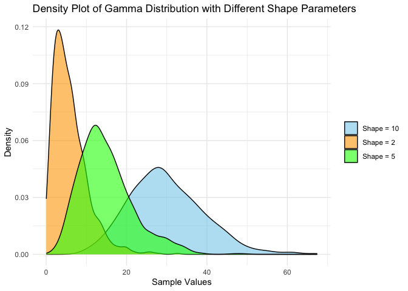

```r
# Create a density plot comparing the three shape parameters
ggplot(df, aes(x = value, fill = shape)) +
  geom_density(alpha = 0.6) +
  labs(title = "Density Plot of Gamma Distribution with Different Shape Parameters",
       x = "Sample Values",
       y = "Density") +
  scale_fill_manual(values = c("skyblue", "orange", "green")) +
  theme_minimal() +
  theme(legend.title = element_blank())
```

### Exercise: Obtain the same plot using built-in R function (i.e., without using ggplot2).

# Question 7

- 1. Generate random sample from standard normal distribution. Plot the histogram of the sample and overlay the density plot on top of it to visualize the distribution.

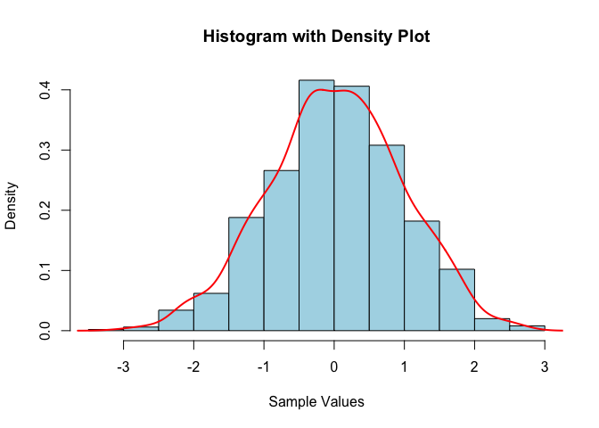

```r
sample_data <- rnorm(1000)
hist(sample_data, probability = TRUE, main = "Histogram with Density Plot",
     xlab = "Sample Values", col = "lightblue", border = "black", breaks = 20)

lines(density(sample_data), col = "red", lwd = 2)
```

- 2. compute the minimum, maximum value, range, mean and variance of your sample data in part (a).

```r
summary_data <- data.frame(
  min = min(sample_data),
  max = max(sample_data),
  range_min = range(sample_data)[1],
  range_max = range(sample_data)[2],
  mean=mean(sample_data),
  variance=var(sample_data)
)
summary_data
```

| min | max | range_min | range_max | mean | variance |
| --- | --- | --- | --- | --- | --- |
| -3.011254 | 2.727949 | -3.011254 | 2.727949 | 0.02433828 | 0.9169129 |

```r
summary(sample_data)
```

```
##     Min.  1st Qu.   Median     Mean  3rd Qu.     Max.
## -3.01125 -0.58938  0.03863  0.02434  0.67632  2.72795
```

```r
# describe(sample_data)
```

# Question 8

Create a function in R that takes two arguments: start and end. This function should generate a sequence of numbers from start to end (inclusive) and then return the sum of all the even numbers in that sequence. Use a for loop to iterate through the sequence and sum the even numbers.

```r
sum_even_numbers <- function(start, end) {
  sum_evens <- 0

  for (i in start:end) {
    if (i %% 2 == 0) {
      sum_evens <- sum_evens + i
    }
  }
  return(sum_evens)
}
```

```r
sum_even_numbers(1, 10)
```

```
## [1] 30
```

# Question 9

Consider the formulas for calculating skewness and kurtosis. Generate a function that can provide both skewness and kurtosis in a list form. Try your function for a random sample generated from Gamma distribution. Check your results with **`skewness()`** and **`kurtosis()`** functions under e1071 package.

Skewness is a measure of the asymmetry of the probability distribution of a real-valued random variable. The formula for skewness is:

$$\text{Skewness} = \frac{1}{n} \sum_{i=1}^{n} \left(\frac{x_i -
\bar{x}}{s}\right)^3$$

Kurtosis measures the “tailedness” of the probability distribution of a real-valued random variable. The formula for kurtosis is:

$$\text{Kurtosis} = \frac{1}{n} \sum_{i=1}^{n} \left(\frac{x_i -
\bar{x}}{s}\right)^4 - 3$$

where:

- $x_i$ is the individual data point,
- $\bar{x}$ is the sample mean,
- $s$ is the sample standard deviation,
- $n$ is the sample size.

```r
# Custom function to calculate skewness and kurtosis
calculate_skew_kurt <- function(data) {
  n <- length(data)
  mean_data <- mean(data)
  sd_data <- sd(data)

  # Skewness calculation (using third central moment)
  skewness <- (1/n) * sum(((data - mean_data) / sd_data)^3)

  # Kurtosis calculation (using fourth central moment)
  kurtosis <- (1/n) * sum(((data - mean_data) / sd_data)^4)-3

  # Return both skewness and kurtosis as a list
  return(list(skewness = skewness, kurtosis = kurtosis))
}

gamma_sample <- rgamma(1000, shape = 2, scale = 3)

# Calculate skewness and kurtosis using the custom function
custom_skew_kurt <- calculate_skew_kurt(gamma_sample)
custom_skew_kurt
```

```
## $skewness
## [1] 1.609807
##
## $kurtosis
## [1] 3.692824
```

```r
library(e1071)
e1071_skewness <- skewness(gamma_sample)
e1071_kurtosis <- kurtosis(gamma_sample)

e1071_skewness; e1071_kurtosis
```

```
## [1] 1.609807
```

```
## [1] 3.692824
```

# Question 10

- 1. Suppose $X \sim \text{Expo}(\lambda=3)$, calculate $P(X > 1)$.

```r
lambda <- 3
x <- 1

prob_exp <- 1 - pexp(x, rate = lambda)
prob_exp
```

```
## [1] 0.04978707
```

```r
pexp(x, rate = lambda, lower.tail = FALSE)
```

```
## [1] 0.04978707
```

```r
# Check the result with the cdf of Exponential
1-(1-exp(-lambda*x))
```

```
## [1] 0.04978707
```

- 2. Suppose $X \sim \text{Poisson}(\lambda=5)$, calculate $P(X \leq 3)$.

```r
lambda_poisson <- 5
x_poisson <- 3

# Calculate the probability
prob_poi <- ppois(x_poisson, lambda = lambda_poisson)
prob_poi
```

```
## [1] 0.2650259
```

```r
1 - ppois(x_poisson, lambda = lambda_poisson, lower.tail = FALSE)
```

```
## [1] 0.2650259
```

**Note:** Explanation of `lower.tail` in R Functions

The `lower.tail` argument is a logical parameter that specifies whether the probability should be calculated for $P[X \leq x]$ or $P[X > x]$.

- If `lower.tail = TRUE` (the default), the function computes $P[X \leq x]$, which represents the cumulative probability up to $x$.
- If `lower.tail = FALSE`, the function computes $P[X > x]$, which is the complement of $P[X \leq x]$, i.e., $P[X > x] = 1 - P[X \leq x]$.

# **Table of R Functions for Random Variables from Different Distributions**

| Distribution | Random Number Generation | Probability Density Function (PDF) | Cumulative Distribution Function (CDF) | Quantile Function (Inverse CDF) |
| --- | --- | --- | --- | --- |
| **Normal** | `rnorm(n, mean, sd)` | `dnorm(x, mean, sd)` | `pnorm(q, mean, sd)` | `qnorm(p, mean, sd)` |
| **Uniform** | `runif(n, min, max)` | `dunif(x, min, max)` | `punif(q, min, max)` | `qunif(p, min, max)` |
| **Exponential** | `rexp(n, rate)` | `dexp(x, rate)` | `pexp(q, rate)` | `qexp(p, rate)` |
| **Binomial** | `rbinom(n, size, prob)` | `dbinom(x, size, prob)` | `pbinom(q, size, prob)` | `qbinom(p, size, prob)` |
| **Poisson** | `rpois(n, lambda)` | `dpois(x, lambda)` | `ppois(q, lambda)` | `qpois(p, lambda)` |
| **Chi-Square** | `rchisq(n, df)` | `dchisq(x, df)` | `pchisq(q, df)` | `qchisq(p, df)` |
| **Gamma** | `rgamma(n, shape, rate)` | `dgamma(x, shape, rate)` | `pgamma(q, shape, rate)` | `qgamma(p, shape, rate)` |
| **Beta** | `rbeta(n, shape1, shape2)` | `dbeta(x, shape1, shape2)` | `pbeta(q, shape1, shape2)` | `qbeta(p, shape1, shape2)` |
| **Log-Normal** | `rlnorm(n, meanlog, sdlog)` | `dlnorm(x, meanlog, sdlog)` | `plnorm(q, meanlog, sdlog)` | `qlnorm(p, meanlog, sdlog)` |
| **T-Distribution** | `rt(n, df)` | `dt(x, df)` | `pt(q, df)` | `qt(p, df)` |
| **F-Distribution** | `rf(n, df1, df2)` | `df(x, df1, df2)` | `pf(q, df1, df2)` | `qf(p, df1, df2)` |

### **Explanation:**

- **Random Number Generation**: These functions generate random numbers based on the respective distribution.
- **Probability Density Function (PDF)**: These functions compute the probability density at a specific point $x$ for continuous distributions (or probability mass for discrete distributions).
- **Cumulative Distribution Function (CDF)**: These functions compute the cumulative probability $P(X \leq q)$ for continuous distributions (or cumulative probability for discrete distributions).
- **Quantile Function**: These functions compute the inverse CDF, returning the value $x$ such that $P(X \leq x) = p$.

# **Table of some built-in R Functions**

| Function | Description | Example Usage |
| --- | --- | --- |
| `abs(x)` | Returns the absolute value of $x$. | `abs(-5)` results in 5 |
| `sqrt(x)` | Returns the square root of $x$. | `sqrt(16)` results in 4 |
| `exp(x)` | Returns $e^x$ (exponential function). | `exp(1)` results in approximately 2.718 |
| `log(x)` | Returns the natural logarithm of $x$. | `log(10)` results in approximately 2.302 |
| `log10(x)` | Returns the logarithm to base 10 of $x$. | `log10(100)` results in 2 |
| `log2(x)` | Returns the logarithm to base 2 of $x$. | `log2(8)` results in 3 |
| `round(x, digits)` | Rounds $x$ to the specified number of decimal places. | `round(3.14159, 2)` results in 3.14 |
| `ceiling(x)` | Returns the smallest integer greater than or equal to $x$. | `ceiling(3.2)` results in 4 |
| `floor(x)` | Returns the largest integer less than or equal to $x$. | `floor(3.8)` results in 3 |
| `signif(x, digits)` | Rounds $x$ to the specified significant digits. | `signif(0.0001234, 3)` results in 0.123 |
| `trunc(x)` | Truncates $x$ to an integer by removing the decimal part. | `trunc(3.9)` results in 3 |
| `factorial(x)` | Computes the factorial of $x$ (for integer values). | `factorial(5)` results in 120 |
| `choose(n, k)` | Computes the binomial coefficient $\binom{n}{k}$. | `choose(5, 2)` results in 10 |
| `gamma(x)` | Returns the Gamma function value for $x$. | `gamma(2)` results in 1 |
| `cor(x, y)` | Computes the correlation between $x$ and $y$. | `cor(c(1,2,3), c(4,5,6))` results in 1 |
| `cov(x, y)` | Computes the covariance between $x$ and $y$. | `cov(c(1,2,3), c(4,5,6))` results in 1 |
| `mean(x)` | Computes the mean (average) of $x$. | `mean(c(1,2,3))` results in 2 |
| `median(x)` | Computes the median of $x$. | `median(c(1,2,3,4,5))` results in 3 |
| `sd(x)` | Computes the standard deviation of $x$. | `sd(c(1,2,3))` results in 1 |
| `var(x)` | Computes the variance of $x$. | `var(c(1,2,3))` results in 1 |

# Matrix Operations in R

Matrix is a two-dimensional data structure in R programming. A matrix is similar to a vector but additionally contains the dimension attribute.

| **Function** | **Description** | **Example Usage** |
| --- | --- | --- |
| `attributes()` | Checks all attributes of an object, including the dimensions of a matrix. | `attributes(my_matrix)` |
| `dim()` | Returns the dimensions (rows and columns) of the matrix. | `dim(my_matrix)` |
| `class()` | Checks if a variable is a matrix. | `class(my_matrix)` |
| `diag()` | Extracts the diagonal elements of a matrix. | `diag(my_matrix)` |
| `det()` | Computes the determinant of a matrix. | `det(my_matrix)` |
| `t()` | Computes the transpose of a matrix (rows become columns and vice versa). | `t(my_matrix)` |
| `solve()` | Computes the inverse of a square matrix. | `solve(my_matrix)` |
| `%*%` | Matrix multiplication operator. Computes the product of two matrices. | `result <- matrix1 %*% matrix2` |